# Day 4 (AM): Data Visualization with ggplot2

## 8.3 Zooming with `coord_cartesian()`

To zoom in without dropping data (which `xlim`/`ylim` inside `scale_` would do):

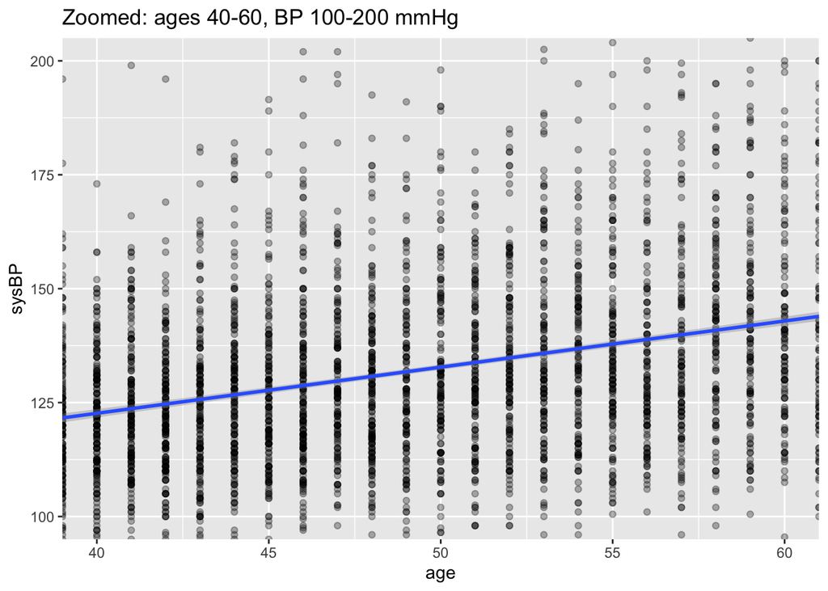

```r
ggplot(framingham, aes(x = age, y = sysBP)) +
  geom_point(alpha = 0.3) +
  geom_smooth(method = "lm") +
  coord_cartesian(xlim = c(40, 60), ylim = c(100, 200)) +
  labs(title = "Zoomed: ages 40-60, BP 100-200 mmHg")
```

# 9 Themes

Themes control all non-data elements: background, grid lines, fonts, and text size.

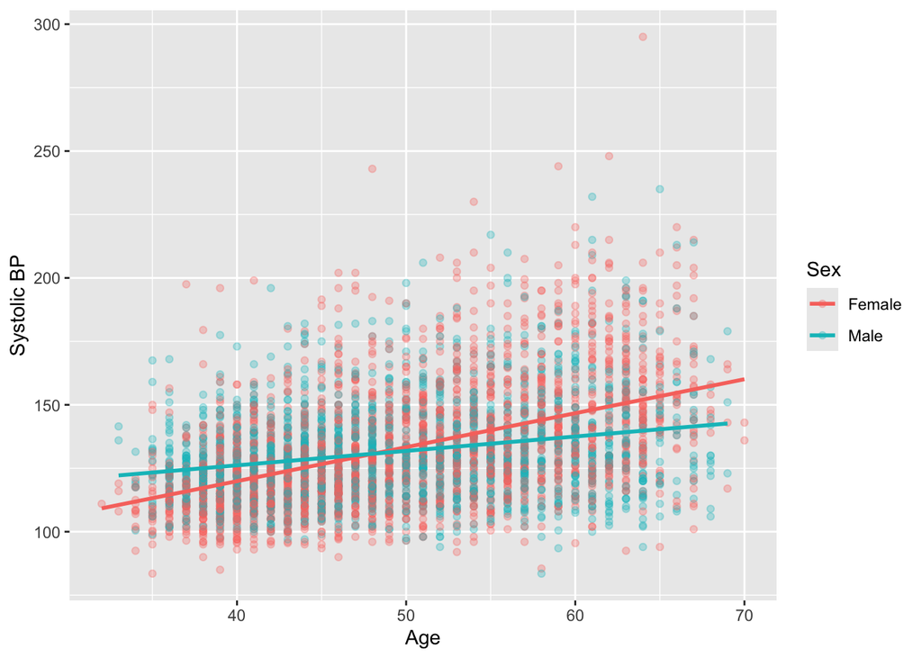

```r
base <- ggplot(framingham, aes(x = age, y = sysBP, color = male)) +
  geom_point(alpha = 0.3) +
  geom_smooth(method = "lm", se = FALSE) +
  labs(x = "Age", y = "Systolic BP", color = "Sex")

base + theme_gray()    # default
```

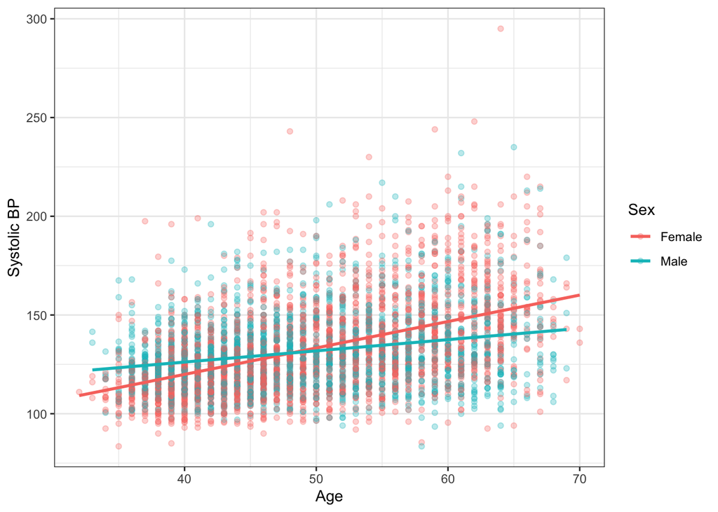

```r
base + theme_bw()      # white background, grid lines
```

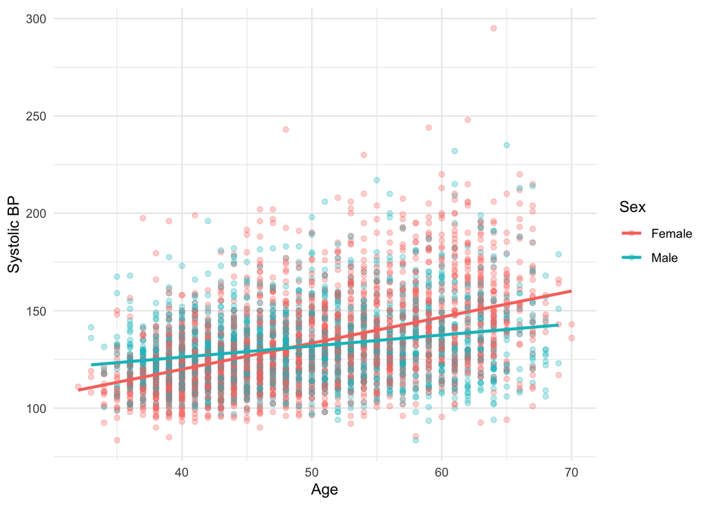

```r
base + theme_minimal() # minimal: no background, light grid
```

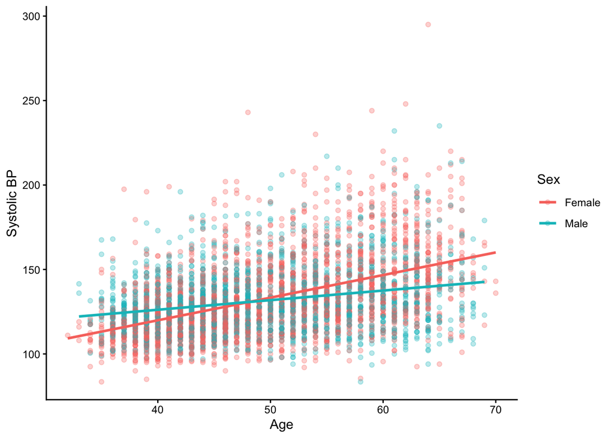

```r
base + theme_classic() # no grid, classic axes
```

Fine-tune individual elements with `theme()`:

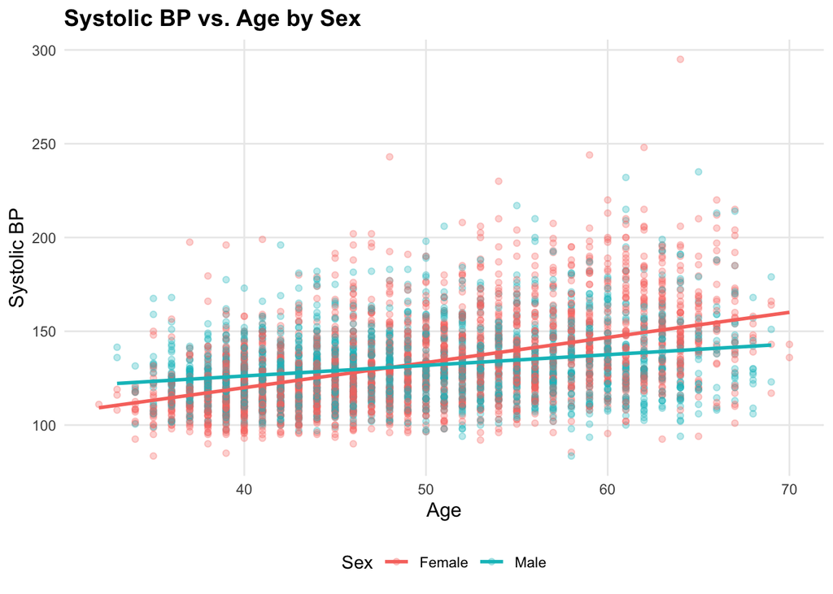

```r
base +
  theme_minimal() +
  theme(
    plot.title       = element_text(size = 14, face = "bold"),
    axis.title       = element_text(size = 12),
    legend.position  = "bottom",
    panel.grid.minor = element_blank()
  ) +
  labs(title = "Systolic BP vs. Age by Sex")
```

# 10 Saving Plots

Use `ggsave()` to write the most recent plot to disk. Always specify `width` and `height` for reproducibility:

```r
ggplot(framingham, aes(x = age, y = sysBP, color = male)) +
  geom_point(alpha = 0.3) +
  geom_smooth(method = "lm", se = FALSE) +
  theme_minimal() +
  labs(x = "Age (years)", y = "Systolic BP (mmHg)", color = "Sex")

ggsave("figures/sysBP_vs_age.png", width = 7, height = 5, dpi = 300)
ggsave("figures/sysBP_vs_age.pdf", width = 7, height = 5)
```

**Tip**

Use `.pdf` for vector graphics (scalable, best for publication) and `.png` for raster graphics (best for slides and web). Always set `dpi = 300` for `.png` to ensure print quality.

When working in Quarto, chunk options control figure output directly — no need for `ggsave()` in most cases:

````markdown
```{r}
#| fig-width: 7
#| fig-height: 5
#| fig-cap: "Systolic BP vs. Age by Sex"
#| fig-alt: "Scatterplot of systolic blood pressure on the y-axis and age on
#|            the x-axis, with separate trend lines by sex."
```
````

# 11 Putting It Together: A Publication-Ready Figure

Here is a complete example building a figure from scratch with all the elements covered today:

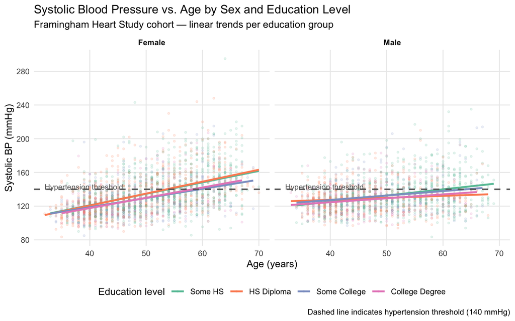

```r
framingham |>
  filter(!is.na(education)) |>
  ggplot(aes(x = age, y = sysBP, color = education)) +
  geom_point(alpha = 0.15, size = 0.8) +
  geom_smooth(method = "lm", se = FALSE, linewidth = 1) +
  geom_hline(yintercept = 140, linetype = "dashed",
             color = "gray40", linewidth = 0.8) +
  annotate("text", x = 32, y = 143,
           label = "Hypertension threshold", color = "gray40",
           hjust = 0, size = 3) +
  scale_color_brewer(palette = "Set2") +
  scale_y_continuous(breaks = seq(80, 300, by = 40)) +
  facet_wrap(~ male) +
  theme_minimal() +
  theme(
    legend.position  = "bottom",
    panel.grid.minor = element_blank(),
    strip.text       = element_text(face = "bold")
  ) +
  labs(
    title    = "Systolic Blood Pressure vs. Age by Sex and Education Level",
    subtitle = "Framingham Heart Study cohort — linear trends per education group",
    caption  = "Dashed line indicates hypertension threshold (140 mmHg)",
    x        = "Age (years)",
    y        = "Systolic BP (mmHg)",
    color    = "Education level"
  )
```

If you think this is crazy, here’s some actual code of mine that I recently used to create a figure:

```r
cols4methods <- c("black","lightsteelblue4"   ,
                  "firebrick1" ,         "palevioletred2",
                  "cornflowerblue","blue1", "darkgoldenrod4" ,
                  "maroon2",               "chartreuse4" , "coral")

shape_vals <- c(15:24)

pos_wid <- 0.88 ## controls the spread of the points and the width of the bars
pos_siz <- 2.5 ## size of the points

# ..... Lots of code missing ......

## Creating the plot. The 'pdf' can be uncommented when creating a pdf of the plot.
mse_plot_fpc <- ggplot(d_plot_mse_fpc %>% filter(M == 5625), aes(x=as.factor(n.basis), y=mean_mse, color = Method)) +
  scale_color_manual(values=cols4methods[c(1,4,5,6)]) +
  geom_errorbar(aes(ymin = min_mser, ymax = max_mser),
                width = pos_wid,
                position=position_dodge(width=pos_wid)) +
  facet_wrap(~sparse_gr) +
  theme_bw() +
  theme_light() +
  geom_point(aes(shape=Method), size=pos_siz, position=position_dodge(width=pos_wid)) +
  scale_shape_manual(values=shape_vals[c(1,4,5,6)]) +
  xlab("Number of Basis Functions") +
  ylab("") +
  theme_bw(base_size = 10, base_family = "Helvetica") +
  theme(strip.background = element_blank(),
        strip.placement = "outside",
        axis.text=element_text(color="#666666",size=8),
        axis.title = element_text(color="#666666",
                                  face="bold", size=11),
        strip.text.x = element_text(size=10),
        strip.text.y = element_text(size=10))

# ..... Lots of code missing ......


mse_plot <- ggplot(d_plot_mse, aes(x=re, y=mean_mse, color = Method)) +
  scale_color_manual(values=cols4methods) +
  geom_errorbar(aes(ymin = min_mser, ymax = max_mser),
                width = pos_wid,
                position=position_dodge(width=pos_wid)) +
  facet_wrap(~M_gr) +
  theme_bw() +
  theme_light() +
  geom_point(aes(shape=Method), size=pos_siz, position=position_dodge(width=pos_wid)) +
  scale_shape_manual(values=shape_vals) +
  xlab("Number of random effects") +
  ylab("Scaled RMSE") +
  theme_bw(base_size = 10, base_family = "Helvetica") +
  theme(strip.background = element_blank(),
        strip.placement = "outside",
        axis.text=element_text(color="#666666",size=8),
        axis.title = element_text(color="#666666",
                                  face="bold", size=11),
        strip.text.x = element_text(size=10),
        strip.text.y = element_text(size=10))


library(ggpubr)

final_plot <- ggarrange(
  mse_plot, mse_plot_fpc,
  labels = c("A", "B"),
  common.legend = TRUE,
  legend = "right",
  nrow = 1)

ggsave("Mse_figA_all.pdf", width = 7, height = 3)
```

[figure not shown]

Here’s the final figure

# 12 Exercises

**Exercise 1.** Make a histogram of BMI in the Framingham data. Try at least three different `binwidth` values. Which reveals the most useful structure? Add a vertical line at BMI = 30 (the obesity threshold) using `geom_vline()` and annotate it with `annotate()`.

**Exercise 2.** Compare the distribution of total cholesterol (`totChol`) across education levels using (a) overlapping density plots with `geom_density()` and (b) boxplots ordered by median cholesterol. Which display is more informative and why? Add proper labels and a theme to both.

**Exercise 3.** Make a scatterplot of `age` vs. `totChol`, colored by `currentSmoker`. Add separate linear trend lines for smokers and non-smokers using `geom_smooth(method = "lm")`. Facet by sex. Use a ColorBrewer palette and `theme_bw()`. What do you notice about the relationship between age and cholesterol for smokers vs. non-smokers?

**Exercise 4.** Using the `diamonds` dataset, make a scatterplot of `carat` vs. `price`. The raw scale will suffer from severe overplotting — solve this with `geom_bin2d()` or `alpha`. Then apply `scale_x_log10()` and `scale_y_log10()`. Label the axes with the original units (carats and dollars) and add a title summarizing the main finding.

**Exercise 5 (Challenge).** Build a single publication-ready figure using Framingham data that shows the 10-year CHD rate (proportion with `TenYearCHD == "Yes"`) by age group and sex. Steps: (a) create an age group variable with `cut()` or `case_when()` (e.g., 30–39, 40–49, 50–59, 60+), (b) compute CHD rate per group using `group_by()` and `summarize()`, (c) plot with `geom_col()` or `geom_line()`, (d) facet or color by sex, (e) add all labels, a sensible theme, and `ggsave()` it to a file.